# Albacore Logbook Distribution Models

## Purpose

We aim to develop simple fishery distribution models for the non-confidential albacore logbook data, to look at spatial patterns and trends. Later, we will use these as a basis for testing the inclusion of albacore habitat suitability from Mary Margaret Stoll’s albacore SDM as a covariate.

```r
library(tidyverse)
library(terra)
library(sf)
library(sdmTMB)
library(viridis)
library(here)
library(rnaturalearth)

tm <- theme_minimal()+theme(panel.border = element_rect(fill=NA,color='black'))
theme_set(tm)
```

## Load data

Albacore logbook data, coarsened to 1 degree resolution.

```r
dat <- read_csv(here('data','logbook','monthly_1D_albacore_logbook_nonconfidential_Apr2026.csv')) |>
  select(-1)
dprop <- read_csv(here('data','logbook','monthly_1D_albacore_logbook_propRemoved_Apr2026.csv')) |>
  select(-1)
```

## Preparing to Model

### Covariate setup

```r
# Add a month column, to use as a covariate
dat <- dat |>
  rename(date=month) |>
  mutate(month=month.name[month(date)]) |>
  # center the "year" column
  mutate(year=year(date)) |>
  mutate(scaled_year=(year-mean(year))/10) |>
  # I think the data are maybe log10(CPUE+1)?? According to Muhling et al. (2019)
  # So, to reverse this for testing purposes
  mutate(cpue=10^mean_logCPUE) |>
  # add a small positive number to zeroes
  # mutate(mean_logCPUE=ifelse(mean_logCPUE==0,0.00001,mean_logCPUE)) |>
  # regime? Before/after 2006
  mutate(regime=ifelse(year<2006,"R1","R2") |> as.factor())
```

### Project data

Project to an planar, azimuthal equal distance projection, to measure distances more accurately when building our models. This is an important step to make sure that spatial relationships in the models are estimated correctly.

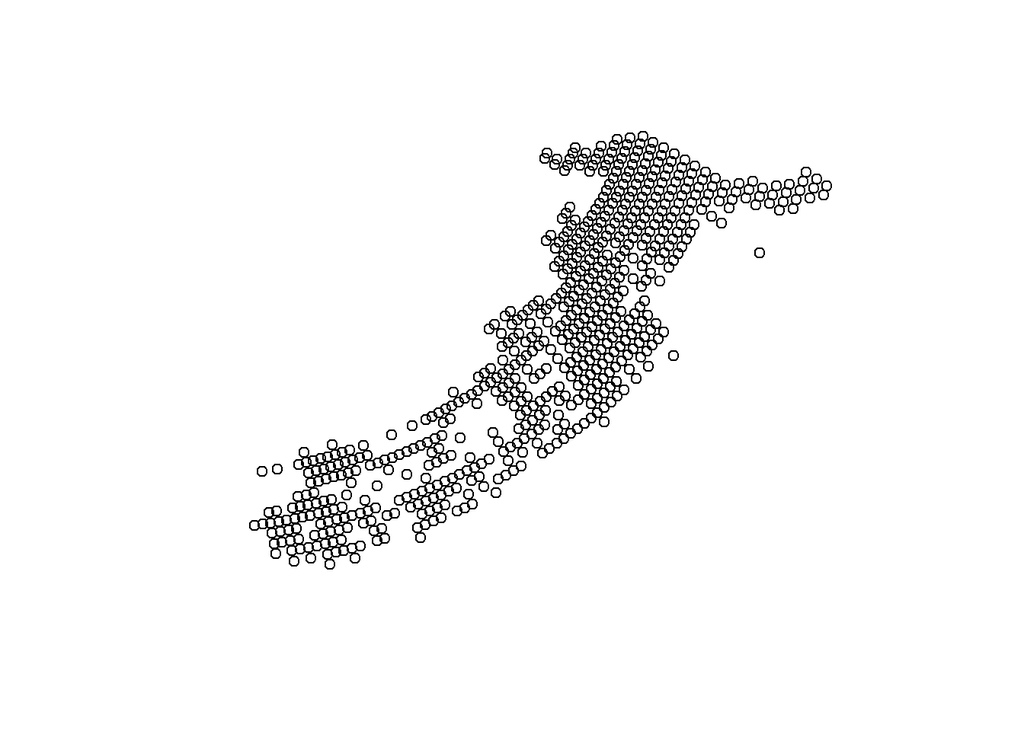

```r
# Custom azimuthal equidistant crs, centered around the median lat/lon of the data
aeqd_crs <- st_crs("+proj=aeqd +lat_0=42 +lon_0=150 +datum=WGS84 +units=m +no_defs")

datproj <- dat |>
  st_as_sf(coords=c("lon_1D","lat_1D"),crs=4326) |>
  st_transform(aeqd_crs)
plot(st_geometry(datproj))
```

```r
xykm <- st_coordinates(datproj)/1000

datproj <- datproj |>
  mutate(Xkm=xykm[,1],Ykm=xykm[,2])
```

### Make mesh

Now we make an SPDE mesh. This is the mesh that will serve as the basis for calculation of our spatial and spatiotemporal fields. Plotted here are the mesh points, with the locations of observed data plotted in the small points underneath.

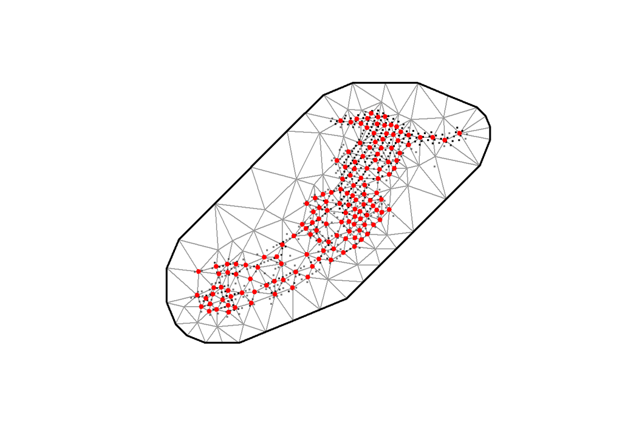

```r
datm <- datproj |> st_set_geometry(NULL)
mesh1 <- make_mesh(datm,xy_cols = c("Xkm","Ykm"),n_knots = 150)
plot(mesh1)
```

Now, we can start to fit some models. Since we do not yet have environmental covariates, for now we will fit these models with just spatial fields, spatiotemporal fields, and year/season effects. Fitting these models will help us understand and visualize the general trends in the distribution of albacore fishing effort over time, even if they likely will not give much information about *why* a certain spatial or temporal pattern arises.

## Fit simple model

In the first test, we fit a model that estimates log CPUE as a combination of an intercept spatial field, a non-spatial and spatial time trend, and a spatial effect of time period (pre- vs. post-2005).

```r
m1 <- sdmTMB(
  mean_logCPUE ~ scaled_year,
  # cpue ~ scaled_year,
  data = datm,
  mesh = mesh1,
  # family = Gamma(),
  # spatial random field
  spatial = "on",
  # NO spatiotemporal field. Instead, spatially varying coefficients on year and regime
  spatial_varying = ~ 1 + scaled_year + regime
)
```

Quick checks- did the model run okay? What are the general parameter estimates?

```r
# did it run ok?
sanity(m1)
# general summary
summary(m1)
```

```
Spatial model fit by ML ['sdmTMB']
Formula: mean_logCPUE ~ scaled_year
Mesh: mesh1 (isotropic covariance)
Data: datm
Family: gaussian(link = 'identity')

Conditional model:
            coef.est coef.se
(Intercept)     0.94    0.57
scaled_year    -0.73    0.49

Dispersion parameter: 0.40
Matérn range: 2562.40
Spatial SD: 0.84
Spatially varying coefficient SD (scaled_year): 0.71
Spatially varying coefficient SD (regimeR2): 0.76
ML criterion at convergence: 1856.362

See ?tidy.sdmTMB to extract these values as a data frame.
```

```r
# main fixed effects
tidy(m1,"fixed")
```

```
# A tibble: 2 × 5
  term        estimate std.error conf.low conf.high
  <chr>          <dbl>     <dbl>    <dbl>     <dbl>
1 (Intercept)    0.942     0.568   -0.172     2.06
2 scaled_year   -0.734     0.490   -1.69      0.226
```

```r
# random effect paramters
tidy(m1,"ran_pars")
```

```
# A tibble: 5 × 5
  term    estimate std.error conf.low conf.high
  <chr>      <dbl>     <dbl>    <dbl>     <dbl>
1 range   2562.    592.      1629.     4032.
2 phi        0.396   0.00509    0.386     0.406
3 sigma_O    0.841   0.199      0.528     1.34
4 sigma_Z    0.708   0.172      0.440     1.14
5 sigma_Z    0.756   0.168      0.488     1.17
```

In these outputs, the main or fixed effects are the intercept and, in this case, the linear effect of year on logCPUE. The `ran_pars` are the random effects, and include the spatial range (a derived parameter that defines the distance at which 2 points are effectively independent), the scale of observation error (`phi`), and the standard deviations of the different spatial fields, explained further below.

### Make grid

To visualize model output, we project the model on to a spatial grid covering our study area. Let’s make the grid.

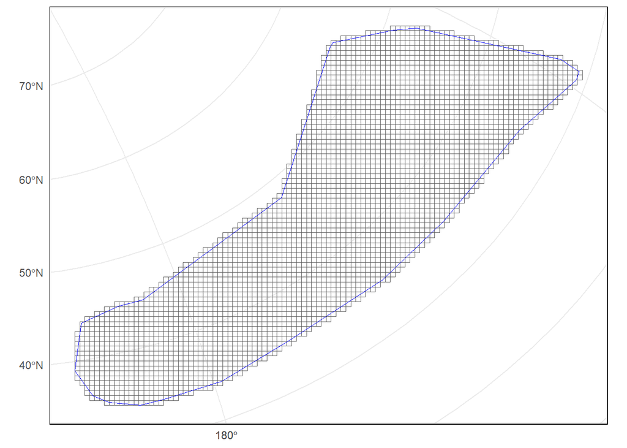

```r
# make an outline around the data, using a concave hull
hull <- st_concave_hull(st_union(datproj),allow_holes=F,ratio=0.5)

# now make a grid and intersect it with the outline, to only keep areas
# near the data. For now, the resolution is 60km (6e4 meters)
npgr <- st_make_grid(hull,square=T,cellsize = 6e4)
ints <- st_intersects(npgr,hull)
npgr <- npgr[lengths(ints)>0,]

ggplot()+geom_sf(data=npgr,fill=NA)+geom_sf(data=hull,fill=NA,color="blue")
```

To project the model, we just need a grid like this as a dataframe, with spatial coordinates and any necessary covariates. In this case, we just replicate the grid once for each year.

```r
# actual prediction dataframe now
gr <- npgr |>
  sf::st_centroid() |>
  sf::st_coordinates() |>
  as_tibble() |>
  # add km columns
  mutate(Xkm=X/1000,Ykm=Y/1000)
# replicate for years
gr_yrs <- replicate_df(gr, "year", unique(dat$year)) |>
  mutate(scaled_year=(year - mean(year)) / 10) |>
  # regime? Before/after 2006
  mutate(regime=ifelse(year<2006,"R1","R2"))
```

### Make predictions

Now we can project the model.

```r
pred <- predict(m1,newdata=gr_yrs)
pred <- pred |>
  rename(year_trend=zeta_s_scaled_year)
```

### Plot spatial trends

Mapping function we can use to generically map a variable of interest.

```r
quickmap <- function(dat, column = est) {
  ggplot(dat, aes(Xkm, Ykm, fill = {{ column }})) +
    geom_raster() +
    coord_fixed() +
    scale_fill_gradient2()
}
```

First, we look at the primary spatial field (i.e., the spatial intercept) for the pre-2006 period. There’s a clear spatial pattern here, of more fishing in the east and west (blue areas), and much less in the middle of the domain (red areas).

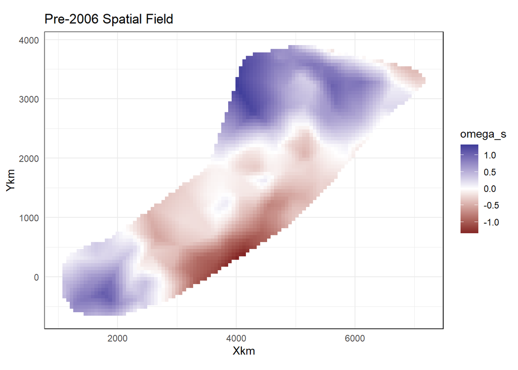

```r
quickmap(pred,omega_s)+
  labs(title="Pre-2006 Spatial Field")
```

And here is the deviation from that field for the post-2005 period. In this period, we see relatively more fishing in most places, including in the middle of the domain. Slightly negative effect right near the US West Coast.

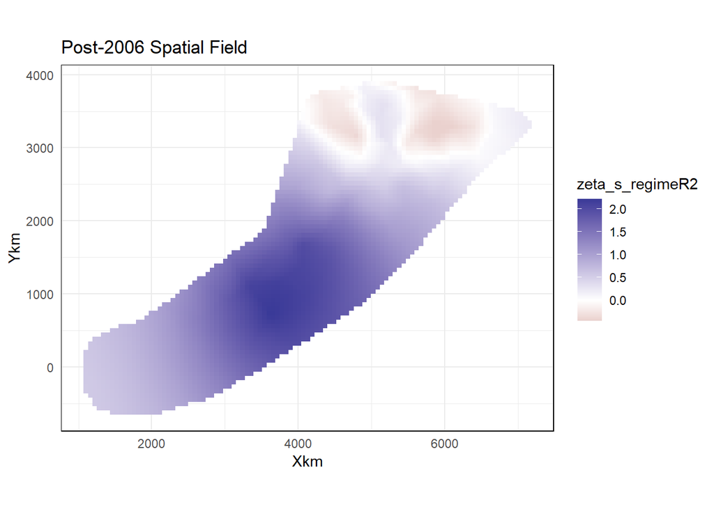

```r
quickmap(pred,zeta_s_regimeR2)+
  labs(title="Post-2006 Spatial Field")
```

However, we also estimated a spatially-varying trend on year. This is the spatial time trend, separate from the other random fields above and separate from the scalar time trend. This actually looks a lot like the pre-2006 spatial field, and describes the linear effect of time on CPUE in different spatial areas.

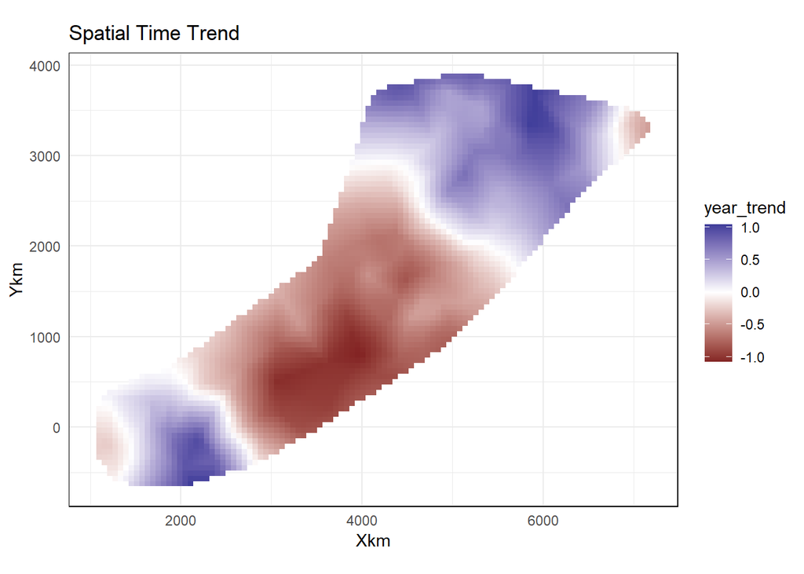

```r
quickmap(pred,year_trend)+labs(title="Spatial Time Trend")
```

If we wanted the effect of year that includes both the spatial field and the scalar trend, we can calculate that:

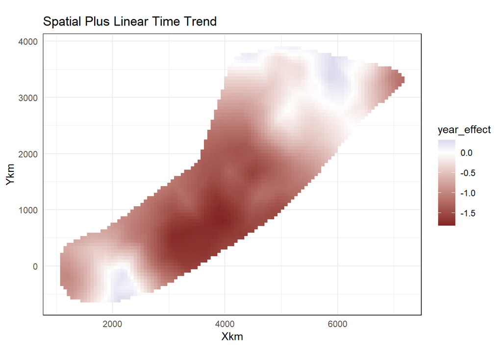

```r
coefs <- tidy(m1,conf.int = T)
scaled_year_coef <- coefs$estimate[coefs$term == "scaled_year"]
pred |>
  mutate(year_effect=scaled_year_coef+year_trend) |>
  quickmap(year_effect)+
  labs(title="Spatial Plus Linear Time Trend")
```

We can also look at the uncertainty around these “spatially-varying coefficients”, using draws from the joint precision matrix of the parameters. For example, for the spatial effect post-2005:

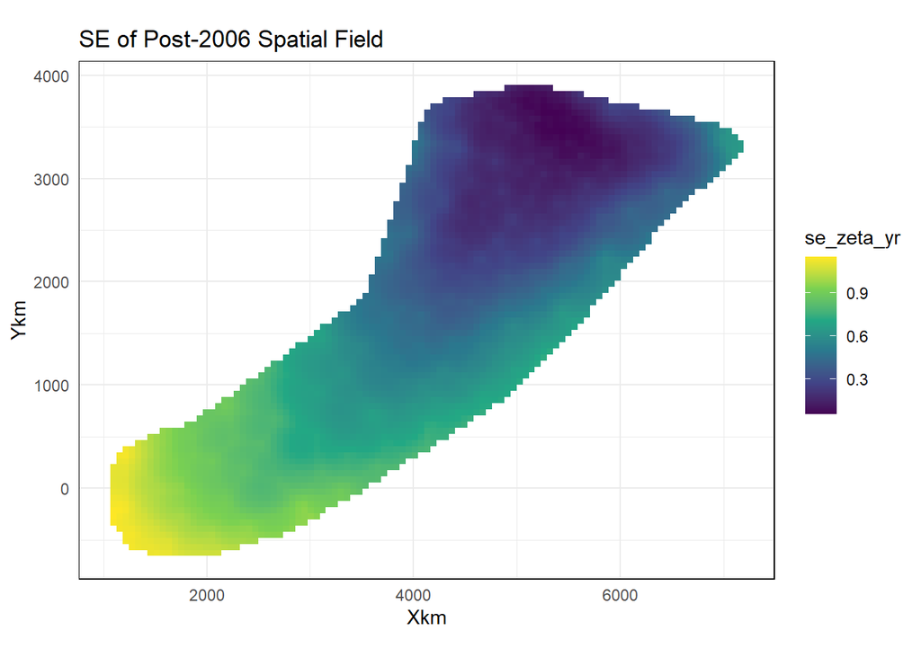

```r
set.seed(890413)
# simulate 200 draws from the joint precision matrix, focusing on varying the regime effect
psim <- predict(m1, newdata = gr_yrs, nsim = 200, sims_var = "zeta_s_regimeR2",return_tmb_report=T)
se_zeta_yr <- map(psim,\(x) pluck(x,"proj_zeta_s_A")[,2,]) |> simplify2array()
pred$se_zeta_yr <- apply(se_zeta_yr,1,sd)
quickmap(pred,se_zeta_yr)+
  scale_fill_viridis_c()+
  labs(title="SE of Post-2006 Spatial Field")
```

```r
rm(psim)
```

Together, we can plot the stacked effect of all random spatial fields by year. This is the intercept spatial field, plus the “regime” (pre vs. post-2006) spatial effect, plus the spatial time trend. This does not include the scalar time trend.

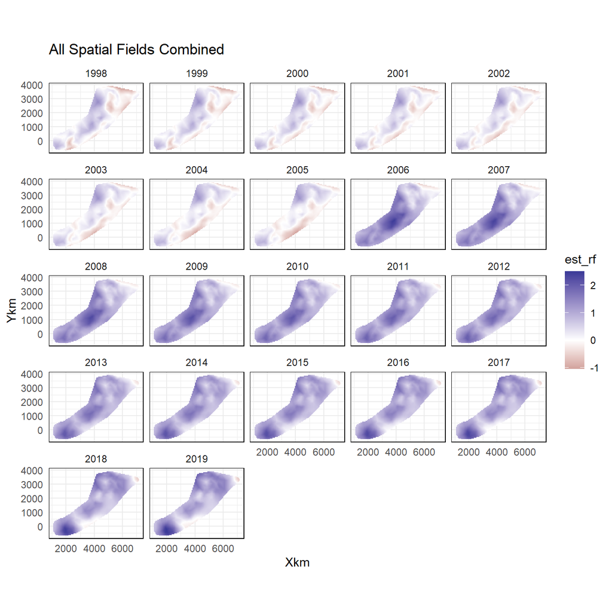

```r
quickmap(pred,est_rf)+
  facet_wrap(~year)+
  labs(title="All Spatial Fields Combined")
```

For comparison, here are the non-spatial effects. This is the scalar intercept plus the scalar time trend (i.e, from the estimated main effects `tidy(m1)`). We can see that these are non-spatial (same value everywhere in a given year).

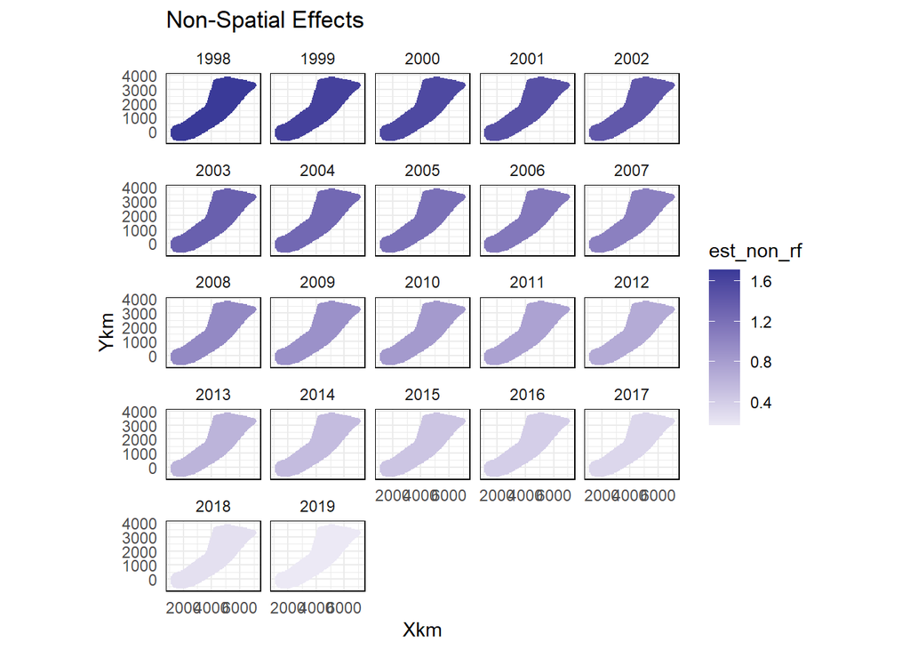

```r
quickmap(pred,est_non_rf)+
  facet_wrap(~year)+
  labs(title="Non-Spatial Effects")
```

### Plot CPUE predictions

Adding everything together, these are the actual CPUE predictions by year

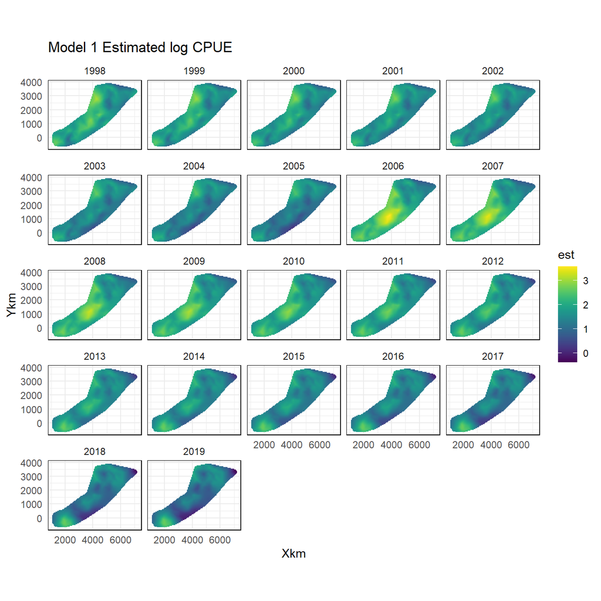

```r
quickmap(pred,est)+
  scale_fill_viridis(option="D")+
  facet_wrap(~year)+
  labs(title= "Model 1 Estimated log CPUE")
```

In (somewhat) natural space, if these values represent log10(CPUE)

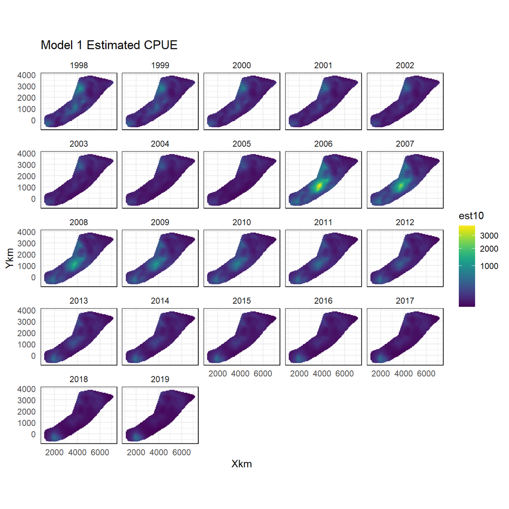

```r
pred |>
  group_by(Xkm,Ykm,year,regime) |>
  summarise(est=mean(est),.groups='drop') |>
  mutate(est10=10^est) |>
  quickmap(est10)+
  facet_wrap(~year)+
  scale_fill_viridis(option='D',trans="sqrt")+
  labs(title= "Model 1 Estimated CPUE")
```

Uncertainty on the CPUE predictions

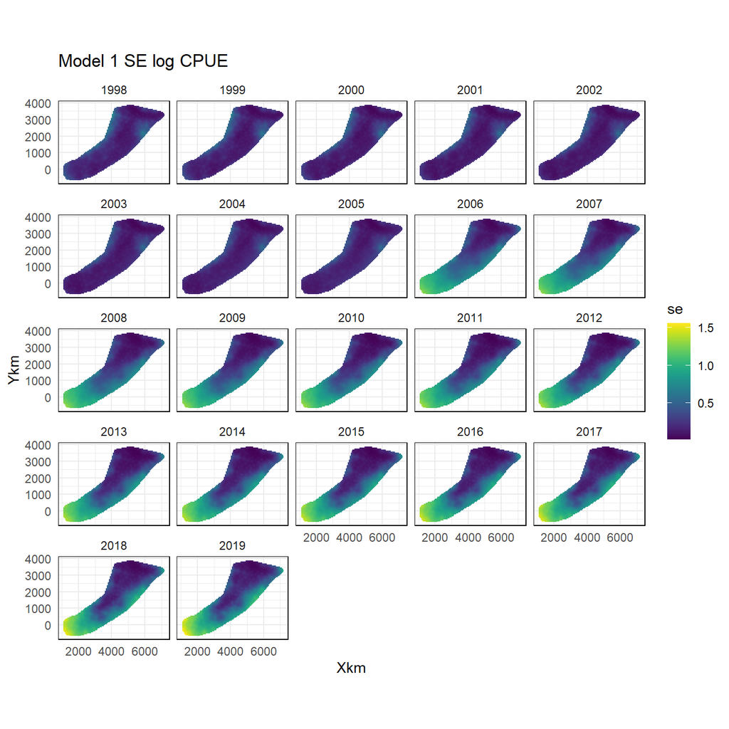

```r
psim <- predict(m1, newdata = gr_yrs, nsim = 200, sims_var = "est")
pred$se <- apply(psim, 1, sd)
quickmap(pred,se)+
  scale_fill_viridis(option="D")+
  facet_wrap(~year)+
  labs(title= "Model 1 SE log CPUE")
```

### Predicted vs. Observed

To perform some diagnostic checks on the model, we want to do some spatial and non-spatial residual checking, and look at the relationship between predicted vs. observed CPUE values. We start by using the model to predict the original data points.

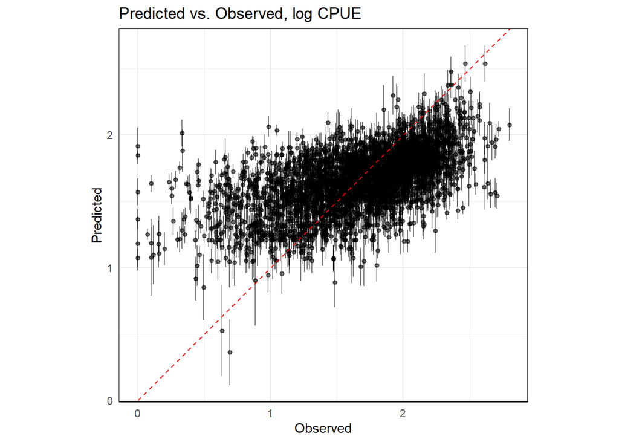

```r
predobs <- predict(m1) |>
  mutate(est10=10^est)
# calculate SE
psim <- predict(m1,nsim=200)
predobs$se_est <- apply(psim,1,sd)

predobs |>
  ggplot(aes(mean_logCPUE,est,ymax=est+se_est,ymin=est-se_est))+
  geom_pointrange(size=0.25,alpha=0.5)+
  coord_equal()+
  labs(x="Observed",y="Predicted",title="Predicted vs. Observed, log CPUE")+
  geom_abline(slope=1,intercept=0,color="red",linetype=2)
```

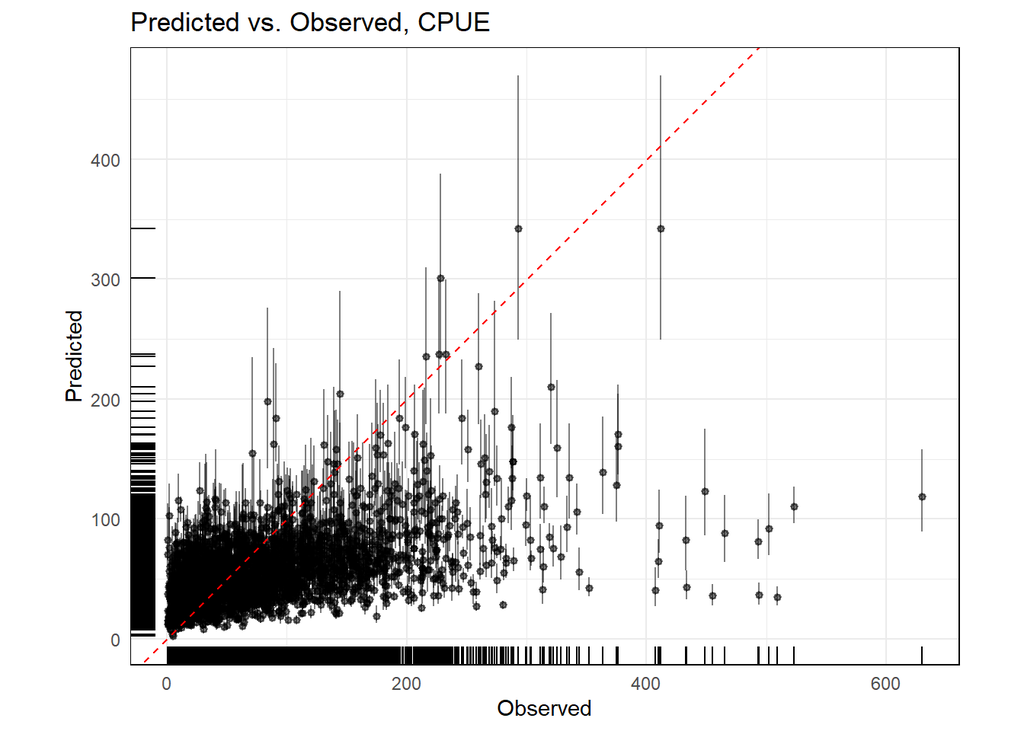

```r
predobs |>
  ggplot(aes(cpue,est10,ymax=10^(est+se_est),ymin=10^(est-se_est)))+
  geom_pointrange(size=0.25,alpha=0.5)+
  geom_rug()+
  coord_equal()+
  labs(x="Observed",y="Predicted",title="Predicted vs. Observed, CPUE")+
  geom_abline(slope=1,intercept=0,color="red",linetype=2)
```

Now make a QQ plot using the `DHARMA` package

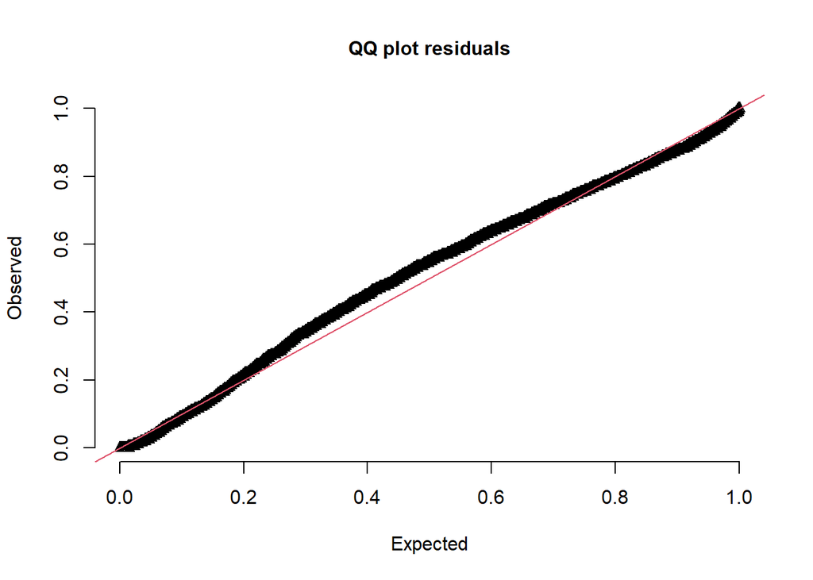

```r
predobs$resids <- residuals(m1)
# qqnorm(predobs$resids);abline(0,1)

# with DHARMA
simresids <- simulate(m1,nsim=200,type = 'mle-mvn')
dharma_residuals(simresids,m1)
```

We can look at how those residuals are distributed in space. Here, we would look for model misspecification if there are large, spatially biased areas with consistently positive or negative residuals, suggesting the model is not performing well in certain places.

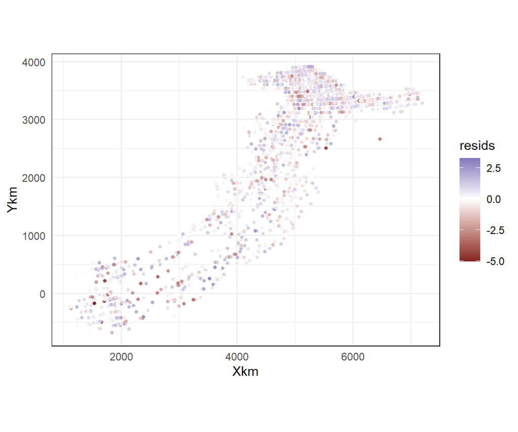

```r
# spatial residuals
predobs |>
  ggplot(aes(Xkm,Ykm,color=resids))+
  geom_jitter(size=1,width = 100)+
  coord_fixed()+
  scale_color_gradient2()
```

This model seems like a pretty good start, but we can explore a couple of other options.

## Model variation - Month/Season

There seems to be significant effects of season, so what if we had a separate spatial field for each group of months, plus a spatial time trend, as above. For now, group the months into May/June, July/Aug/Sep, and Oct/Nov. The idea behind the parameterization is to let the model estimate a linear time trend and a spatial time trend, but also control for the average distribution of fishing across months.

### Month/Season

Add a factor indicator for month groups

```r
datm <- datm |>
  mutate(season=case_when(
    month=="May"|month=="June" ~ "MJ",
    month%in%c("July","August","September") ~ "JAS",
    month %in% c("October","November") ~ "ON"
  )) |>
  mutate(seasonfct=factor(season,levels=c("MJ","JAS","ON")))
```

Now fit the model

```r
m2 <- sdmTMB(
  mean_logCPUE ~ scaled_year,
  data = datm,
  mesh = mesh1,
  family = gaussian(link="identity"),
  # spatial random field
  spatial = "on",
  # NO spatiotemporal field. Instead, spatially varying coefficients on year and month
  spatial_varying = ~ 1 + scaled_year + seasonfct
)
```

As with the first model above, we can perform a series of initial checks on model performance. Unlike Model 1 that has two spatial fields for pre- and post-2006, this model has three spatial fields for the three groups of months.

```r
# did it run ok?
sanity(m2)
# quick summary
summary(m2)
```

```
Spatial model fit by ML ['sdmTMB']
Formula: mean_logCPUE ~ scaled_year
Mesh: mesh1 (isotropic covariance)
Data: datm
Family: gaussian(link = 'identity')

Conditional model:
            coef.est coef.se
(Intercept)     1.30    0.16
scaled_year    -0.28    0.14

Dispersion parameter: 0.40
Matérn range: 1138.79
Spatial SD: 0.45
Spatially varying coefficient SD (scaled_year): 0.36
Spatially varying coefficient SD (seasonfctJAS): 0.21
Spatially varying coefficient SD (seasonfctON): 0.15
ML criterion at convergence: 1840.108

See ?tidy.sdmTMB to extract these values as a data frame.
```

```r
# main fixed effects
tidy(m2,"fixed")
```

```
# A tibble: 2 × 5
  term        estimate std.error conf.low conf.high
  <chr>          <dbl>     <dbl>    <dbl>     <dbl>
1 (Intercept)    1.30      0.156    0.993    1.60
2 scaled_year   -0.283     0.136   -0.549   -0.0166
```

```r
# random effect paramters
tidy(m2,"ran_pars")
```

```
# A tibble: 6 × 5
  term    estimate std.error conf.low conf.high
  <chr>      <dbl>     <dbl>    <dbl>     <dbl>
1 range   1139.    225.      774.      1676.
2 phi        0.396   0.00512   0.386      0.406
3 sigma_O    0.448   0.0791    0.317      0.633
4 sigma_Z    0.360   0.0799    0.233      0.556
5 sigma_Z    0.214   0.0896    0.0945     0.486
6 sigma_Z    0.152   0.0934    0.0456     0.507
```

### Make predictions

Predict to the regular grid. We need a new (larger) grid that includes all three groups of months for each year. So, this prediction dataframe will be three times the size of the one used for Model 1 above, because we are adding the effect of months within years.

```r
yrs_season <- crossing(seasonfct=unique(datm$seasonfct),year=unique(datm$year)) |>
  mutate(scaled_year=(year-mean(year))/sd(year))
gr_ssn_yrs <- map(1:nrow(yrs_season),\(x) gr |> bind_cols(yrs_season[x,])) |> bind_rows()
```

Now predict.

```r
pred2 <- predict(m2,newdata=gr_ssn_yrs)
pred2 <- pred2 |>
  rename(year_svc=zeta_s_scaled_year)
```

### Spatial fields

We do not have regime now, so the spatial fields are the intercept, a deviation from that intercept for each block of months, and the spatial time trend. First, the spatial intercept, which includes the first factor level of season (i.e., May/June):

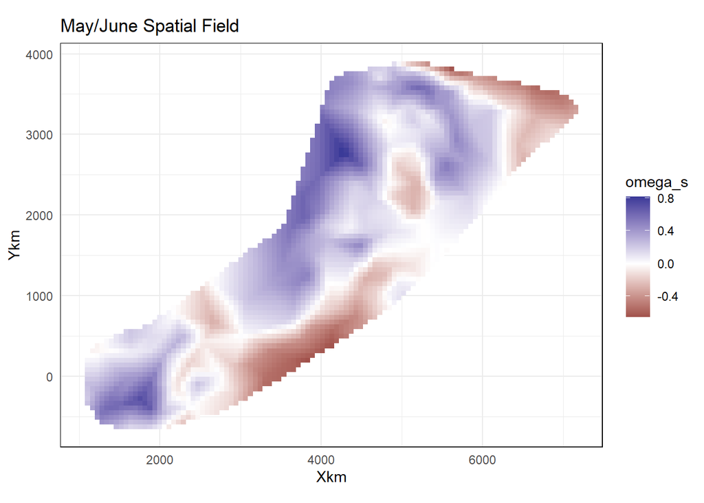

```r
quickmap(pred2,omega_s)+
  labs(title="May/June Spatial Field")
```

The deviation for July/August/September.

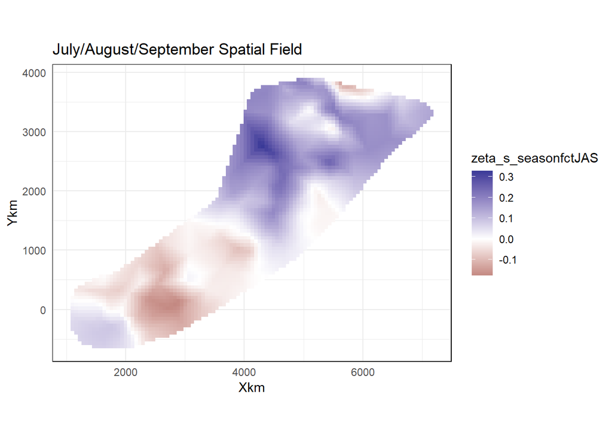

```r
quickmap(pred2,zeta_s_seasonfctJAS)+
  labs(title="July/August/September Spatial Field")
```

And for October/November.

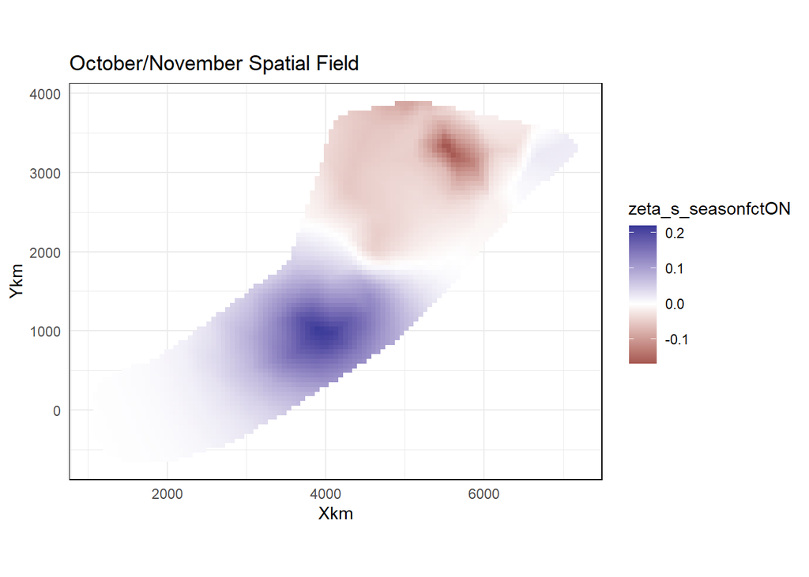

```r
quickmap(pred2,zeta_s_seasonfctON)+
  labs(title="October/November Spatial Field")
```

### Spatial trends

Now, the spatial time trend again, including the scalar time trend. But now (as opposed to model 1), we have “factored out” the season spatial fields.

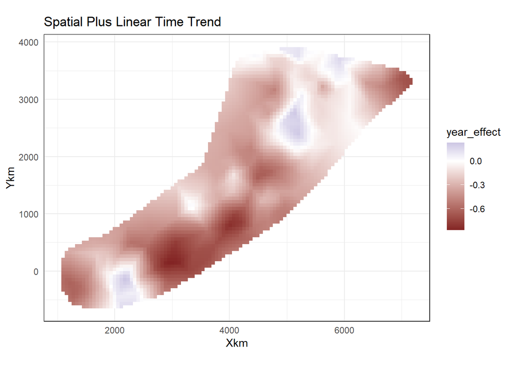

```r
coefs <- tidy(m2,conf.int = T)
scaled_year_coef <- coefs$estimate[coefs$term == "scaled_year"]
pred2 |>
  mutate(year_effect=scaled_year_coef+year_svc) |>
  quickmap(year_effect)+
  labs(title="Spatial Plus Linear Time Trend")
```

All random spatial fields together, by month across years.

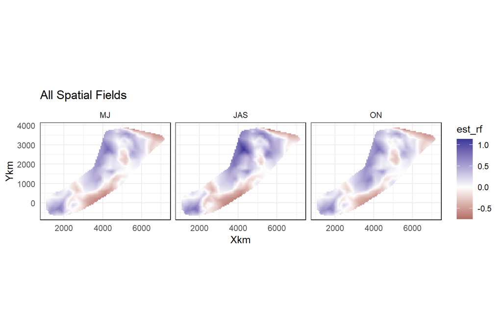

```r
pred2 |>
  group_by(Xkm,Ykm,seasonfct) |>
  summarise(est_rf=mean(est_rf),.groups='drop') |>
  quickmap(est_rf)+
  labs(title="All Spatial Fields")+facet_wrap(~seasonfct)
```

### CPUE predictions

Mean predicted CPUE by month across years:

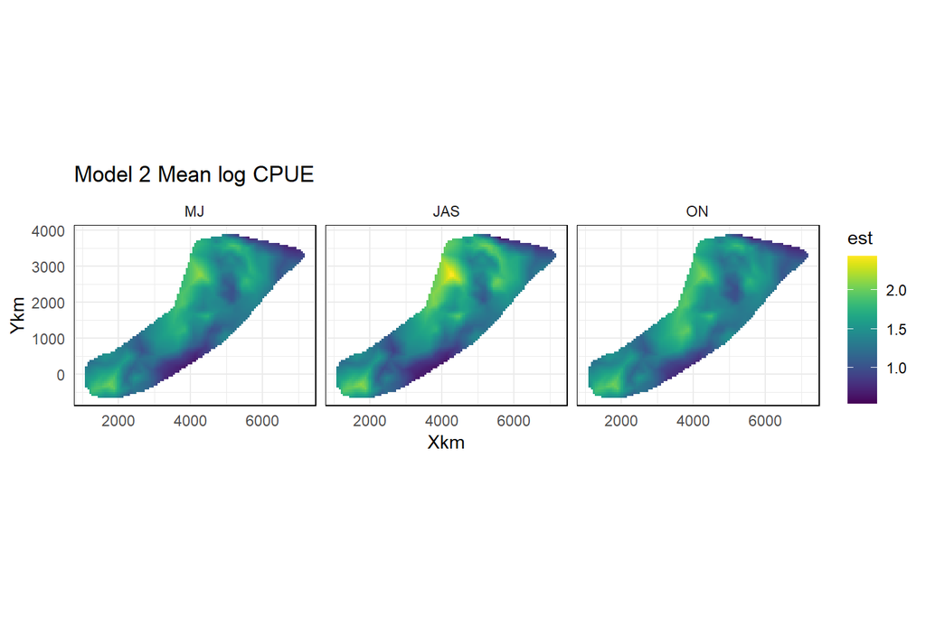

```r
pred2 |>
  group_by(Xkm,Ykm,seasonfct) |>
  summarise(est=mean(est),.groups='drop') |>
  quickmap(est)+
  scale_fill_viridis(option="D")+
  labs(title="Model 2 Mean log CPUE")+
  facet_wrap(~seasonfct)
```

Uncertainty

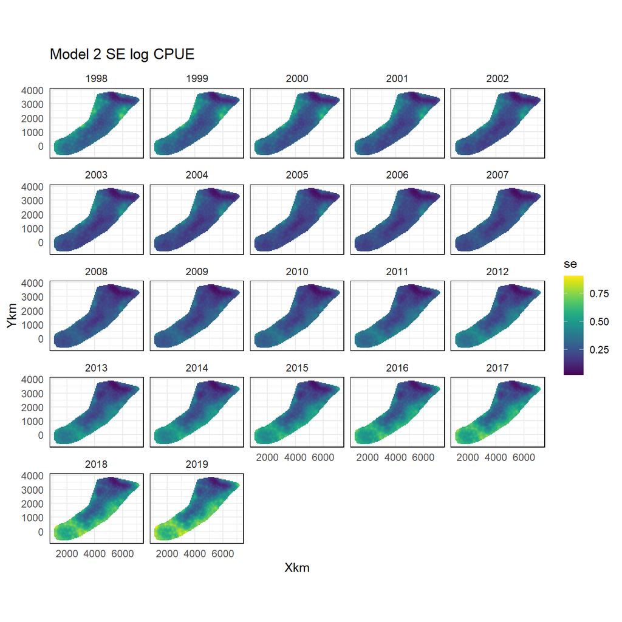

```r
psim <- predict(m2, newdata = gr_ssn_yrs, nsim = 200, sims_var = "est")
pred2$se <- apply(psim, 1, sd)
quickmap(pred2,se)+
  scale_fill_viridis(option="D")+
  labs(title="Model 2 SE log CPUE")+
  facet_wrap(~year)
```

### Predicted/observed

Again, for model checks we predict to the original data points

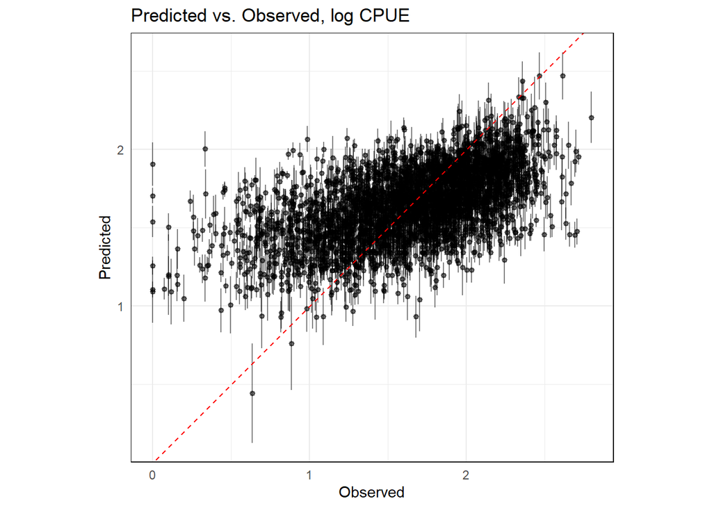

```r
predobs <- predict(m2)
psim <- predict(m2,nsim=200)
predobs$se_est <- apply(psim,1,sd)

predobs |>
  ggplot(aes(mean_logCPUE,est,ymax=est+se_est,ymin=est-se_est))+
  geom_pointrange(size=0.25,alpha=0.5)+
  coord_equal()+
  labs(x="Observed",y="Predicted",title="Predicted vs. Observed, log CPUE")+
  geom_abline(slope=1,intercept=0,color="red",linetype=2)
```

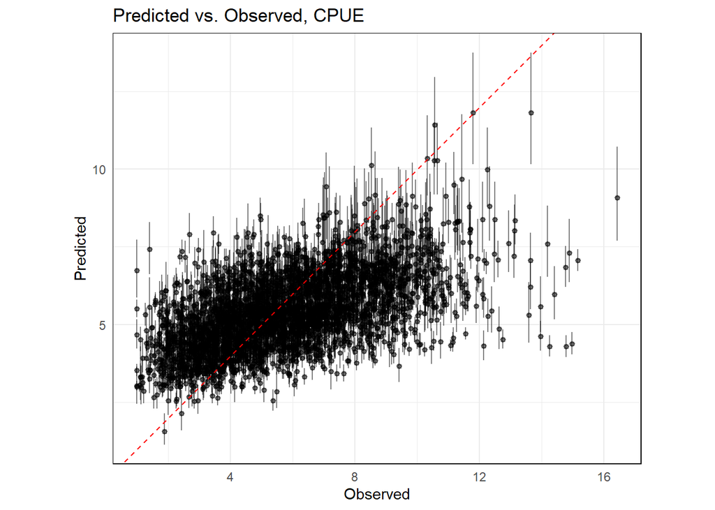

```r
predobs |>
  ggplot(aes(exp(mean_logCPUE),exp(est),ymax=exp(est+se_est),ymin=exp(est-se_est)))+
  geom_pointrange(size=0.25,alpha=0.5)+
  coord_equal()+
  labs(x="Observed",y="Predicted",title="Predicted vs. Observed, CPUE")+
  geom_abline(slope=1,intercept=0,color="red",linetype=2)
```

QQ plot

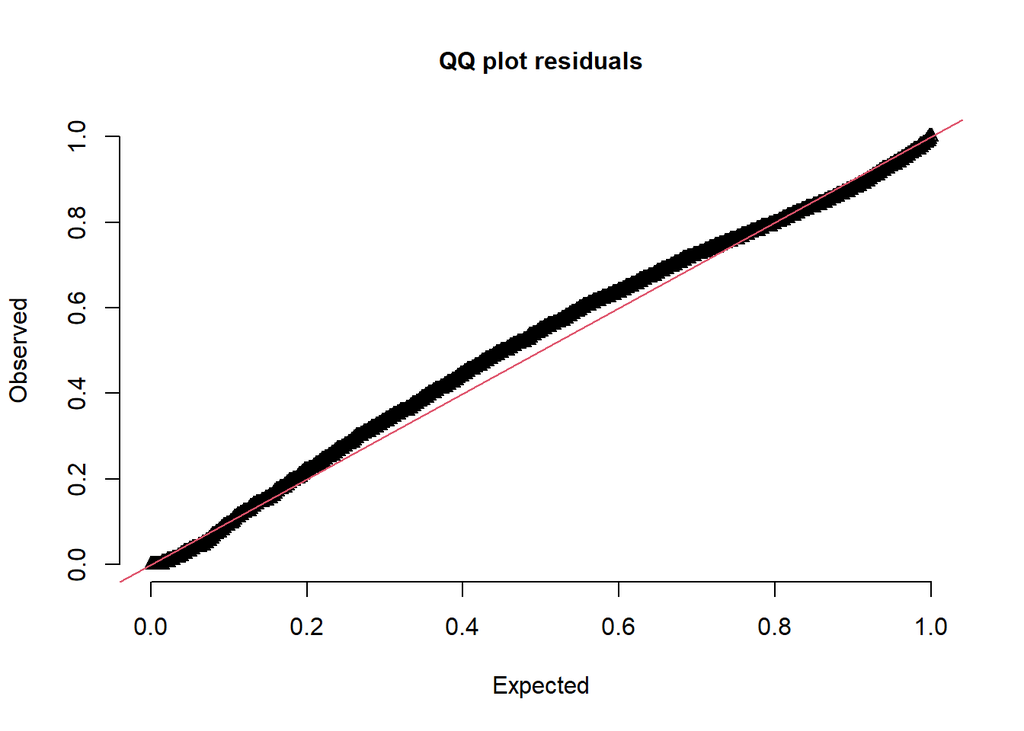

```r
predobs$resids <- residuals(m2)
# qqnorm(predobs$resids);abline(0,1)

# with DHARMA
simresids <- simulate(m2,nsim=200,type = 'mle-mvn')
dharma_residuals(simresids,m2)
```

## Model variation - spatiotemporal

For a 3rd model to compare, we fit a separate spatial field for each year - a spatiotemporal field. These could be correlated (e.g., AR1 or random walk) or independent (IID). We keep them independent for now. The spatiotemporal fields represent annual deviations from the other spatial fields.

Model 3 estimates a scalar intercept, a scalar time trend, a baseline spatial field, IID spatiotemporal fields for each year, and we retain the spatial fields for each group of months. In this model we also allow anisotropy (`anisotropy = T`), which means that the underlying spatial process can have a larger range (i.e., correlation range) in one spatial direction than another.

```r
m3 <- sdmTMB(
  mean_logCPUE ~ scaled_year,
  data = datm,
  mesh = mesh1,
  family = gaussian(link="identity"),
  # spatial random field
  spatial = "on",
  spatiotemporal = "iid",
  anisotropy = T,
  time="year",
  # we still have a spatial field by season
  spatial_varying = ~ 1 + seasonfct
)
```

Quick model checks

```r
# did it run ok?
sanity(m3)
# quick summary
summary(m3)
```

```
Spatiotemporal model fit by ML ['sdmTMB']
Formula: mean_logCPUE ~ scaled_year
Mesh: mesh1 (anisotropic covariance)
Time column: character
Data: datm
Family: gaussian(link = 'identity')

Conditional model:
            coef.est coef.se
(Intercept)     1.37    0.10
scaled_year    -0.15    0.07

Dispersion parameter: 0.31
Matérn anisotropic range (spatial): 708.9 to 1245.6 at 141 deg.
Spatial SD: 0.32
Spatially varying coefficient SD (seasonfctJAS): 0.15
Spatially varying coefficient SD (seasonfctON): 0.31
Spatiotemporal IID SD: 0.42
ML criterion at convergence: 1370.719

See ?tidy.sdmTMB to extract these values as a data frame.
See ?plot_anisotropy to plot the anisotropic range.
```

```r
# main fixed effects
tidy(m3,"fixed")
```

```
# A tibble: 2 × 5
  term        estimate std.error conf.low conf.high
  <chr>          <dbl>     <dbl>    <dbl>     <dbl>
1 (Intercept)    1.37     0.102     1.17     1.58
2 scaled_year   -0.149    0.0667   -0.280   -0.0186
```

```r
# random effect paramters
tidy(m3,"ran_pars")
```

```
# A tibble: 7 × 5
  term      estimate std.error conf.low conf.high
  <chr>        <dbl>     <dbl>    <dbl>     <dbl>
1 phi          0.310   0.00435   0.302      0.319
2 sigma_O      0.322   0.0472    0.242      0.430
3 sigma_E      0.421   0.0240    0.377      0.471
4 sigma_Z      0.147   0.0608    0.0654     0.331
5 sigma_Z      0.307   0.0811    0.183      0.515
6 range_min  709.     NA        NA         NA
7 range_max 1246.     NA        NA         NA
```

We can look at the estimated anisotropy, showing that this model has the highest range (i.e., largest de-correlation distance) in the NW/SE direction (141 degrees on the compass).

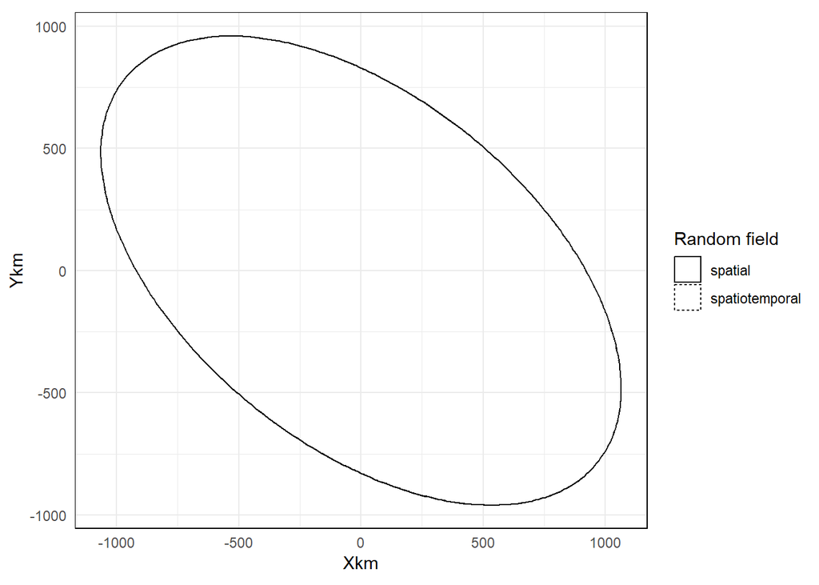

```r
plot_anisotropy(m3)
```

### Make predictions

To predict, we can use the same grid as Model 2.

```r
pred3 <- predict(m3,newdata=gr_ssn_yrs)
```